# How accurate is altitude from pressure geolocators?

A global assessment of three pressure-to-altitude conversions on the ground and in flight

**Background.** Pressure geolocators record atmospheric pressure throughout the year on small birds, and pressure sensors also provide vertical records in GPS-equipped tags. The altitudes derived from these records reveal migration strategies and inform conservation assessments, including exposure to wind turbines. However, pressure-to-altitude conversions make assumptions about atmospheric conditions whose consequences for altitude error remain poorly quantified.

**Methods.** We evaluated three conversions: a fixed standard atmosphere, a conversion using local ERA5 surface conditions, and an ERA5 conversion additionally accounting for virtual temperature and a climatological temperature lapse rate from GPT3. Treating reference pressures as exact conversion inputs, we compared estimates with 2,130 GHCNh weather stations worldwide and IGRA2 radiosondes from 643 stations up to 6 km above ground. We summarize absolute errors by their medians and 95th percentiles, distinguish station bias from within-station SD, and weight flight-height errors by the flight time of 203 tracked birds.

**Results.** At screened ground-reference stations, the standard atmosphere produced a median absolute error of 40.3 m, with 5% of absolute errors exceeding 148 m. Local ERA5 conditions reduced these to 4.1 m and 23 m, respectively. In flight, flight-time-weighted median absolute errors were 20.6 m with the standard atmosphere, 6.9 m with ERA5, and 5.5 m after adding virtual temperature and GPT3. At 2–3 km, the correction reduced the median station bias from -33.2 m to -5.5 m. At 2–3 km above ground, the 95th percentile of absolute flight-height error fell from 237 m with the standard atmosphere to 84 m with the corrected ERA5 conversion.

**Conclusions.** Local atmospheric conditions substantially reduce the large altitude errors introduced by a fixed standard atmosphere; virtual temperature and a climatological lapse rate further reduce systematic flight-height errors. The conversion is computationally simple and available in a software function using measured pressure, measurement time and an estimated geographic position. Remaining atmospheric and sensor errors must still be considered when interpreting flight behaviour or classifying flights relative to turbine heights.

**Keywords:** biologging, barometric altimetry, flight altitude, ERA5, radiosonde, multi-sensor geolocator, GeoPressureR

# 1 Background

Altitude is a central dimension of how birds use their environment [1]. In flight, it helps explain how migrants adjust their flight heights in relation to winds, temperature and visibility [2–4], how aerial insectivores’ foraging heights vary with atmospheric conditions [5], and how birds exploit rising air to reduce flight costs [6]. Synchronized changes in flight height can identify birds travelling together, as demonstrated in bee-eaters [7]. Vertical records also document twilight ascents in swifts [8], exploratory climbs during migration [9], and pronounced day–night changes in flight altitude during barrier crossings [10–12]. On the ground, elevation describes habitat use and movements such as elevational commuting, uphill roosting and seasonal migration [13–15]. Flight-height data also inform conservation assessments, including exposure to wind turbines [16, 17] and the effects of artificial light at night on migratory flight height [18].

Lightweight multi-sensor geolocators equipped with pressure sensors make it possible to study the vertical movements of small birds throughout their annual cycle [19–21]. Their low power requirements allow pressure to be recorded over long deployments, but interpreting these records requires converting pressure into altitude. The same conversion is also needed when pressure sensors complement GPS tracking [6, 16, 22]. Interpreting these records requires knowing how accurately pressure can be converted into altitude, and whether the resulting uncertainty is small enough to resolve the movements or height differences of interest [23].

Pressure-to-altitude conversion requires a reference pressure at a known altitude and an estimate of the temperature profile between that level and the bird. The simplest approach assumes a fixed standard atmosphere [24], as implemented in pamlr [25], and continues to be used in recent geolocator studies [9, 21, 26–28]. To account for weather-driven pressure changes, studies have used nearby weather-station observations [5, 15]. Reanalysis provides reference conditions across space and time, allowing this correction to be applied along migratory tracks; Meier et al. [8], for example, used reanalysis sea-level pressure while retaining a standard temperature profile. Local surface temperature can also be incorporated, as implemented in GeoPressureR using ERA5 surface pressure, temperature and elevation [29, 30], and applied in subsequent geolocator studies [12, 17]. Schaub et al. [31] further refined the temperature profile by estimating a lapse rate between the model surface and an upper-air pressure level, requiring additional temperature and geopotential fields from the ERA5 pressure-level dataset.

Previous evaluations have established the performance of pressure-derived heights in controlled device trials [32], at grounded birds [31], and through comparisons with GPS during flight [33]. In GPS-tracked birds, behavioural classification can identify periods at a known height, such as floating at sea level, that provide calibration references [16, 33]. Comparable ground-level references cannot be reliably established along geolocator tracks, where uncertain positions limit the assignment of local ground elevation. These studies establish device and calibration performance, and the benefit of reanalysis correction has also been illustrated [30]. For long geolocator deployments, however, a geographically broad comparison is needed to establish how atmospheric conversion errors vary with climate, terrain and flight height. Evaluating alternative conversions against common reference observations would quantify the gains from local weather information and temperature-profile refinements, while distinguishing persistent bias from temporal variability.

Here, we compare three pressure-to-altitude conversions: a fixed standard atmosphere, an ERA5 surface reference with the standard lapse rate, and the same reference with virtual temperature and a climatological lapse rate from GPT3 [34]. Using worldwide weather stations, stations with documented pressure-sensor heights and radiosonde profiles up to 6 km above the ground, we quantify atmospheric conversion errors on the ground and in flight. We distinguish systematic bias from temporal variability, characterize the range of errors, and summarize flight-height errors using the heights of tracked birds. Our aim is to establish how much local atmospheric information and a more realistic temperature profile improve a conversion suitable for long pressure records.

# 2 Methods

## 2.1 Three conversions from pressure to altitude

Pressure decreases with height because each layer of air supports the weight of the air above it. Combining this hydrostatic approximation with the ideal gas law gives the hypsometric relation [35]:
$$z = z_0 + \frac{R\,\bar T_v}{g\,M}\,\ln\frac{p_0}{p},
\tag{1}$$
with $z$ the altitude (m) at pressure $p$, $z_0$ and $p_0$ the altitude and pressure of a reference level, $g$ = 9.80665 m s$^{-2}$, $R$ = 8.31432 J mol$^{-1}$ K$^{-1}$, $M$ = 0.0289644 kg mol$^{-1}$, and $\bar T_v$ the mean virtual temperature.

The virtual temperature $T_v = T(1 + 0.608\,q)$, with $T$ the air temperature in kelvin and $q$ the specific humidity, accounts for moist air being lighter than dry air. Temperature can vary with height; the conversion uses the mean virtual temperature between the reference level and the bird, weighted by increments of log pressure:
$$\bar T_v = \frac{1}{\ln(p_0/p)}\int_p^{p_0} T_v(p')\,d\ln p'.$$
To simplify the computation, temperature is assumed to change at a constant rate with height, giving a linear profile $T(z)=T_0+L(z-z_0)$, where $T_0$ is the reference temperature in kelvin. This rate, called the lapse rate $L=dT/dz$ (K m$^{-1}$), is negative when temperature decreases with height. Without a humidity correction, $T_v=T$, and integration gives the barometric equation:
$$z = z_0 + \frac{T_0}{L}\left[\left(\frac{p}{p_0}\right)^{-R L / (g M)} - 1\right].
\tag{2}$$
The three conversions differ in their reference level and in the column temperature they assume. Figure 1 illustrates the effects of weather-driven pressure changes and temperature-profile assumptions on altitude estimates:

1. **Standard atmosphere.** The reference is sea level ($z_0$ = 0, $p_0$ = 1013.25 hPa) with $T_0$ = 288.15 K (15 °C) and $L$ = $-6.5$ K km$^{-1}$ [24]. Its main advantage is that it needs no external data, but these fixed conditions do not account for changes in pressure, temperature or humidity.
2. **ERA5, standard lapse rate.** The ERA5 reanalysis provides surface pressure $p_0$, 2 m air temperature $T_0$ and surface geopotential $\Phi$ at the location and hour of each measurement, with reference altitude $z_0=\Phi/g$. This accounts for local pressure and temperature variations, while retaining a constant lapse rate of $-6.5$ K km$^{-1}$ and no humidity correction.
3. **ERA5, virtual temperature and GPT3 lapse rate.** This conversion adds two refinements to the ERA5 reference. First, humidity at the reference level is accounted for by replacing $T_0$ in Equation 2 with the reference-level value of $T_v$. The specific humidity $q$ needed for this correction is calculated from ERA5 surface pressure $p_0$ and 2 m dewpoint $T_d$, via vapour pressure $e$ [36]:

$$q=\frac{0.622\,e}{p_0-0.378\,e}, \qquad e=611.2\exp\left(\frac{17.67\,T_d}{T_d+243.5}\right),$$

where $T_d$ is in °C and $p_0$ and $e$ are in Pa. Second, the standard lapse rate is replaced with a location- and season-dependent value from GPT3, an empirical troposphere model that provides a lapse rate for any location and time of year [34]. Values are interpolated bilinearly on the 1° grid. This formulation does not resolve humidity aloft.

All three conversions are implemented in R. Both ERA5 conversions are available in the GeoPressureR function `pressure_to_altitude()` (`altitude_formula = "standard"` or `"virtual"`). ERA5 single-level variables [37] are read from the ECMWF ARCO archive at the nearest 0.25° grid cell and hour.

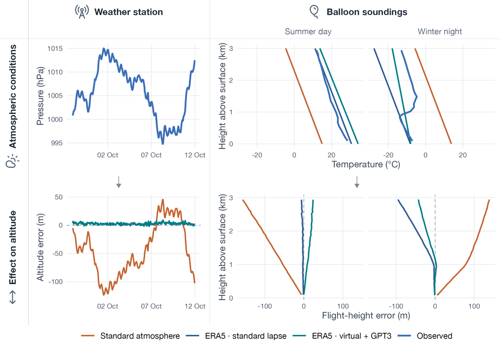

Figure 1: Atmospheric conditions and their effects on pressure-derived altitude. Left: observed pressure at Cape Naturaliste, Australia (reported elevation 109 m), from 28 September to 11 October 2026, and altitude errors from the three conversions for this stationary sensor. Right: radiosonde temperatures and assumed temperature profiles for a temperate summer day at Tampa Bay, USA (31 July 2026), and a continental winter night at Lincoln, USA (19 December 2025), with corresponding flight-height errors below. The teal profile represents virtual temperature. For each sounding, reference conditions near 2 km are held fixed throughout the illustration, and flight-height errors subtract each conversion’s estimate at the launch surface. Dashed lines mark zero error. The weather station and two-week period were selected near median temporal variability among flat temperate stations and within that station, respectively; the sounding examples were selected near their class-median errors at 2 km.

## 2.2 Reference datasets

We test pressure-to-altitude conversion in two settings: at weather stations with reported elevations, and during balloon ascents, where measured pressure can be compared with the reported height profile. Figure 2 shows the locations used in both comparisons; full data-screening criteria are in Additional file 1: S1.

### 2.2.1 Ground-level reference: GHCNh

For the ground comparison, we use NOAA’s [Global Historical Climatology Network hourly](https://www.ncei.noaa.gov/products/global-historical-climatology-network-hourly) (GHCNh) archive [38], which provides hourly surface pressure and station elevation. We select one station per represented 200 km equal-area cell, using its latest qualifying 12-month window within 2022–2026. To ensure the reported elevation is a useful reference, we remove pressure observations outside 300–1100 hPa or marked as suspect by GHCNh, then exclude stations with large persistent pressure-derived elevation offsets from ERA5, abrupt changes or frequent implausible readings. This retains 2,130 stations; full thresholds are given in Additional file 1: S1. Each retained pressure report is paired with ERA5 conditions from the nearest hour.

Because listed station elevation may not exactly match pressure-sensor height, we also assess two ground references with more explicit height information: pressure sensors at GNSS stations with checked site-log metadata and MeteoSwiss stations with published pressure-sensor heights. These comparisons test how reference-height information affects the results and are presented in Additional file 1: S4.

### 2.2.2 Flight-height reference: IGRA2

To assess how conversion error changes above the surface, we use balloon soundings from NOAA’s [Integrated Global Radiosonde Archive, version 2 (IGRA2)](https://www.ncei.noaa.gov/products/weather-balloon/integrated-global-radiosonde-archive) [39–41]. Radiosondes measure pressure as they rise and report the corresponding atmospheric height. We compare pressure-derived height changes with reported height changes, from the surface to 6 km above it, using 643 stations and the latest qualifying 12-month windows within 2022–2026. Each profile level is paired with ERA5 conditions from the nearest hour.

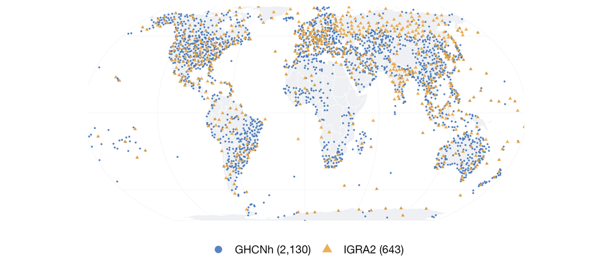

Figure 2: Weather stations and radiosonde launch sites used to evaluate pressure-derived altitude at the surface and through the atmosphere. Station counts are shown in brackets; complementary ground references are described in Additional file 1: S4.

## 2.3 Error metrics

We treat reference pressures as exact conversion inputs and define error as estimated minus reference height. We use the same summaries on the ground and in flight. For **individual observations**, the median absolute error describes a typical error magnitude; the 95th percentile of absolute error describes the upper tail. For **stations**, bias is the mean signed error and SD describes variability around that mean. We report weighted medians across stations: absolute station bias, |bias|, on the ground, and signed station bias in flight to retain the direction of height error. Median |bias| describes a persistent station offset; it differs from the median absolute error of individual observations.

**On the ground**, error is converted altitude minus the reported reference elevation. Individual hourly errors describe single reports; station bias and SD separate persistent offsets from temporal variability. Each retained GHCNh station receives equal weight, divided among its accepted hourly observations; GNSS and MeteoSwiss stations receive equal weight. All three conversions use the same records and weights. Because the GHCNh plausibility screen uses ERA5 residuals, we compare it with coverage-only selection within the same represented cells (Additional file 1: S5). Terrain, season, local time and climate are assessed in Additional file 1: S2.

**In flight**, error is the converted height difference from the sounding surface minus the corresponding radiosonde height difference. Individual absolute errors are summarized within height bands. Station bias and SD are calculated across retained levels and soundings within each station–height band, separating persistent offsets from variation among profiles and levels. Figure 4 shows their weighted medians and station interquartile ranges in 250 m bands. Within each reporting band, contributing stations receive equal weight, divided equally among their retained levels.

For the overall bird summary, we use the same median absolute error, with each height band’s error distribution weighted by its share of recorded flight time. These shares are estimated from 203 tagged birds of 25 species in the Master GeoLocator Data Package [42], accounting for the sampling interval represented by each record (Figure 4 c). The weighted median is calculated from the combined individual-error distribution, rather than by averaging band medians. It describes this sample’s height distribution, not an individually validated bird flight. The construction of these weights and an equal-tag comparison are described in Additional file 1: S6.

# 3 Results

## 3.1 Ground altitude errors

Across 2,130 screened GHCNh stations, the median / 95th percentile of absolute hourly errors fell from 40.3 / 148 m with the standard atmosphere to 4.1 / 23 m with ERA5 and the standard lapse rate (Figure 3). These pooled errors describe individual reports; the station summaries separate persistent offsets from temporal variability. The weighted median station |bias| and SD fell from 26.0 and 52.1 m, respectively, to 3.1 and 3.4 m with ERA5. Adding virtual temperature and the GPT3 lapse rate made little difference to ground errors.

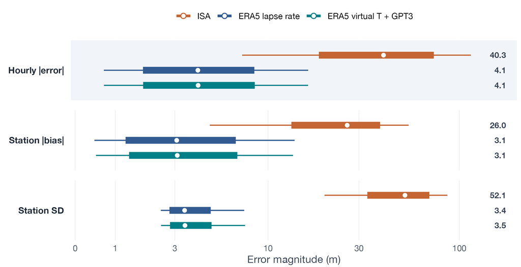

Figure 3: Ground errors at screened GHCNh stations. The lightly shaded top panel shows the weighted distribution of absolute errors across hourly observations. The lower panels group station-level absolute bias and within-station SD, separating persistent offsets from temporal variability. Thick segments show the weighted 25th–75th percentiles, thin segments the 10th–90th percentiles, and white dots mark weighted medians; numbers at the right give those medians in metres. All panels share a pseudo-log x-axis (linear near zero and logarithmic for larger errors; sigma = 1 m); each retained station contributes equal total weight.

Station offsets and variability were larger in rougher terrain: median |bias| rose from 2.6 m in flat terrain (sub-grid ERA5 orography SD below 20 m) to 6.8 m in mountains (above 300 m); station SD rose from 3.0 to 8.1 m. The ERA5 median absolute hourly error was similar with the references that provide more explicit pressure-sensor heights: 3.0 m at 49 GNSS stations and 4.2 m at 138 MeteoSwiss stations, compared with 4.1 m at GHCNh (Additional file 1: S4). At 3 matched Swiss stations, substituting published pressure-sensor height for listed GHCNh elevation reduced median |bias| from 1.6 to 1.4 m. This indicates that height metadata can account for part of the remaining offset at these sites, without establishing the cause of discrepancies at other stations (Additional file 1: S4).

## 3.2 Flight-height errors

At individual profile levels, median absolute error at 2–3 km above the sounding surface was 93.4 m with the standard atmosphere, 32.2 m with ERA5 and the standard lapse rate, and 24.5 m with virtual temperature and GPT3. The corresponding 95th percentiles of absolute error were 237, 120 and 84 m. At station level, Figure 4 separates signed bias from within-station SD: the corrected conversion brings the median station bias towards zero, while variation among profiles and levels remains. At 2–3 km, adding virtual temperature and GPT3 shifted median station bias from -33.2 to -5.5 m, while median station SD remained similar (34.2 and 33.8 m). These station summaries use the full 2–3 km reporting band, while Figure 4 uses finer bands.

After weighting profile-level errors by the tracked birds’ flight-time distribution across height bands, median absolute error fell from 20.6 to 6.9 and 5.5 m. All these errors are referenced to each sounding’s own surface and exclude the absolute ground-reference error.

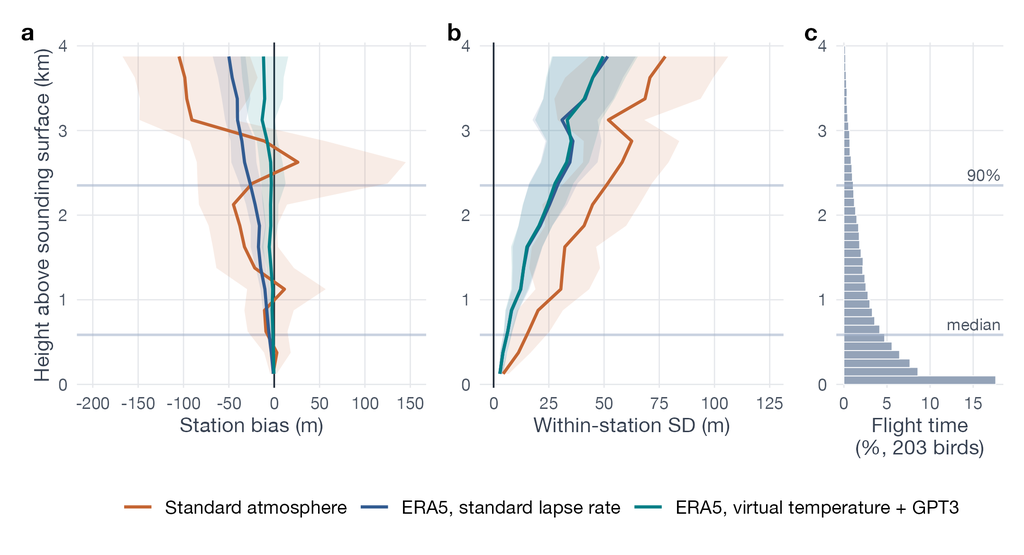

Figure 4: Surface-referenced flight-height errors against height above the sounding surface: (a) station bias (mean error; negative: height underestimated) and (b) station error SD within each height band. Lines: equally weighted medians across stations in 250 m height bands; shaded bands: weighted 25th–75th percentiles for all three conversions. Curves join observed-band summaries without smoothing; the highest band is centred at 3.875 km. These station quantiles differ from the pooled individual-error summaries. The display covers 0–4 km; error calculations extend to 6 km. (c) Flight-time height distribution of 203 birds, with its median (590 m) and 90th percentile (2,350 m) marked across the panels.

# 4 Discussion

Our results support a practical improvement to pressure-derived bird altitudes: combine local ERA5 surface conditions with virtual temperature and a GPT3 lapse rate. Accounting for weather provides the largest gain, reducing median absolute ground error from 40.3 to 4.1 m. The profile refinements provide an additional benefit in flight, bringing systematic height bias towards zero while leaving much of the within-station variability unchanged. Together, these improvements reduce flight-time-weighted median absolute error from 20.6 m with the standard atmosphere to 5.5 m. Both the weather inputs and the lapse-rate climatology are openly available, making the combined conversion a practical option for long tracking records.

Reducing these errors can help distinguish ecological patterns from atmospheric variation. At a fixed ground elevation, weather-driven pressure changes can appear as gradual, continuous elevation changes when converted with a standard atmosphere. Correcting for weather helps separate this apparent movement from the timing and magnitude of actual elevational movements. In flight, the ecological importance of an altitude error depends on the vertical scale of the question: a difference of a few tens of metres may leave a broad description of kilometre-high migration unchanged, yet matter when estimating exposure to turbine rotors [16, 33], responses to urban environments and artificial light [18, 43], or flight relative to topography [44]. For example, a radar experiment found a mean flight-height reduction of about 23 m under white-light treatment [18], illustrating that ecologically relevant responses can occur at this scale. These applications motivate more accurate individual tracking records, although their sensitivity to our correction remains to be evaluated. Atmospheric errors also vary with season and time of day (Additional file 1: S2), so comparisons of altitude among these conditions can inherit conversion differences. The bird-weighted summary describes the sampled distribution of flight time, and giving each tag equal weight preserves the conversion ranking (Additional file 1: S6); height-specific errors remain more relevant to a particular flight or narrow height range.

The atmospheric information needed for correction need not make altitude estimation cumbersome. Weather-station and reanalysis references have already been used in bird studies [5, 8, 31], but fixed standard-atmosphere conversions also remain in use [9, 26, 27]. ERA5 provides hourly atmospheric conditions across the globe [29, 37], allowing weather correction without obtaining local station measurements along a track. GPT3 adds a reusable global climatology of geographic and seasonal lapse-rate variation [34]; virtual temperature requires the additional surface humidity information available from ERA5. GeoPressureR combines these inputs in its pressure-to-altitude workflow [45], so the refinements require little additional user effort once pressure, time and an estimated position are available. High horizontal precision is not a prerequisite for useful atmospheric correction: in our ten-station pilot near 2 km, displacing the query by 50 km changed the corrected absolute-altitude median error by less than 1 m, while the median absolute change in paired estimates was about 5 m (Additional file 1: S7). Individual changes were larger in the tail, and these results concern atmospheric annotation rather than identifying terrain beneath a bird.

The choice of atmospheric inputs nevertheless matters. ERA5-Land’s finer grid did not improve ground altitude and produced larger persistent offsets across the three reference networks, whereas surface-referenced flight errors were similar between products (Additional file 1: S3). This pattern points to differences in the surface reference and supports using ERA5 single-level conditions for the evaluated conversion. For the atmospheric column, the virtual-temperature/GPT3 correction reduces recurring bias without requiring a temperature profile for every measurement. Its limited effect on within-station scatter is consistent with a climatology that cannot reproduce each day’s conditions, including inversions. Variable lapse rates derived from ERA5 pressure levels have already been used in bird tracking [31], and fuller atmospheric profiles have been evaluated for barometric altitude in aviation [46]. Comparing such approaches with the present conversion would establish when their additional data requirements yield a useful improvement for tracking records.

The remaining uncertainty depends on the quantity being interpreted (Table 1). Persistent ground offsets can partly cancel in comparisons at one site, making relative elevation changes less sensitive to those offsets than absolute elevations, although temporal variability remains. Both offsets and variability increase in rough terrain. Sensor offset and drift add uncertainty beyond the atmospheric conversion; known-height events, such as floating periods in seabirds, can help calibrate records [16, 33]. Such calibration complements weather correction but does not determine the temperature profile aloft. Controlled laser-reference trials [32] and evaluations at grounded birds [31] address complementary parts of the measurement process, so their reported errors cannot be directly ranked against our conversion errors. Local ground clearance additionally requires terrain or sea-surface elevation in a consistent vertical reference [23, 47]. For example, the corrected conversion’s absolute-error p95 of 20 m at 100–250 m is relative to the sounding surface; it excludes absolute surface-reference error and added sensor error. It therefore represents only part of the uncertainty relevant to a bird’s position relative to a rotor or terrain feature.

Table 1: Summary of evaluated conversion errors (m). Ground: median absolute station bias in flat terrain and mountains (sub-grid ERA5 orography SD below 20 m and above 300 m), and median within-station SD, at screened GHCNh stations. Flight: median absolute profile-level error relative to the sounding surface; the final row additionally weights the combined error distribution by recorded bird flight time. All values exclude added tag-sensor error; the ground comparison retains reference-height uncertainty.

| Quantity | Standard atm. | ERA5 standard | ERA5 virtual + GPT3 |
| --- | --- | --- | --- |
| Ground, flat terrain (median \|bias\|) | 23.4 | 2.6 | 2.6 |
| Ground, mountains (median \|bias\|) | 43.0 | 6.8 | 7.4 |
| Within-station scatter (median SD) | 52.1 | 3.4 | 3.5 |
| Flight, 1–1.5 km (median \|error\|) | 55.4 | 13.7 | 9.3 |
| Flight, 2–3 km (median \|error\|) | 93.4 | 32.2 | 24.5 |
| Flight-time weighted (median \|error\|) | 20.6 | 6.9 | 5.5 |

The reference comparisons constrain how far these findings transfer to deployed tracking records. Ground errors depend on reference-height information and on selection: the ERA5-based GHCNh checks can exclude genuine model discrepancies as well as suspect records. The coverage-only comparison preserves the conversion ranking, with a larger effect on upper-tail errors than on medians (Additional file 1: S5). The paired Swiss height substitution illustrates a metadata contribution at those sites, while GNSS and MeteoSwiss provide complementary references with more explicit sensor heights (Additional file 1: S4). These comparisons do not establish independence from ERA5 assimilation. Reported radiosonde heights can likewise be derived from the measured atmospheric profile, so our flight comparison primarily tests the assumed atmospheric column rather than independently measured geometric height. ERA5 assimilates conventional surface and upper-air observations [29]; assimilation of the evaluated records was not determined. Balloon drift, uneven geographic coverage and the absence of offshore references further limit transfer. Within this scope, the results support using readily accessible weather and climatological information to reduce avoidable conversion errors, while selecting uncertainty summaries appropriate to the height, vertical reference and ecological question.

# 5 Conclusions

A fixed standard atmosphere introduces substantial errors into pressure-derived bird altitudes. At screened ground-reference stations, its median absolute error was 40.3 m and 5% of absolute errors exceeded 148 m. Referencing the conversion to local ERA5 conditions reduced these to 4.1 and 23 m. In flight, the standard-atmosphere 95th percentile of absolute error reached 237 m at 2–3 km above ground, even after referencing each flight height to its own surface. ERA5 greatly reduced these errors, while virtual temperature and a GPT3 lapse rate further reduced flight-time-weighted median absolute error from 6.9 to 5.5 m. These improvements support more reliable interpretation of migration altitude and reduce one source of uncertainty in conservation assessments.

The corrected conversion is computationally simple: it combines surface atmospheric variables with a climatological lookup and is available in a single software function. Users supply measured pressure and obtain atmospheric conditions using an estimated bird position at the measurement time; no measured temperature profile aloft is required. This makes the correction practical for long geolocator records. It substantially reduces conversion error, while day-to-day temperature profiles, unresolved terrain, pressure-sensor errors and position uncertainty still constrain individual altitude estimates, particularly near ecological or turbine-height thresholds.

# 6 Declarations

**Ethics approval and consent to participate.** Not applicable: no animals were handled for this study; the bird flight heights come from published tracking data.

**Consent for publication.** Not applicable.

**Availability of data and materials.** Code, derived tables, figures and data-archive instructions are available at https://github.com/GeoPressure/altitude-validation [48]. The bird weighting uses the open-access Master GeoLocator Data Package, version 2026.0 [42]; the release-specific DOI and verified input checksums accompany the derived weights. The conversions are implemented in GeoPressureR [45]. GHCNh, IGRA2, GNSS, MeteoSwiss and ERA5 data are openly available from their providers (Additional file 1: S1 and S4).

**Competing interests.** The authors declare that they have no competing interests.

# 7 References

1. Nilsson C, Shamoun-Baranes J, Satterfield DA, Sjöberg S, Cohen EB. Animal niches in the airspace. Trends in Ecology & Evolution. 2025;40:1101–12. https://doi.org/10.1016/j.tree.2025.08.006.

2. Kemp MU, Shamoun-Baranes J, Dokter AM, Loon E van, Bouten W. The influence of weather on the flight altitude of nocturnal migrants in mid-latitudes. Ibis. 2013;155:734–49. https://doi.org/10.1111/ibi.12064.

3. Senner NR, Stager M, Verhoeven MA, Cheviron ZA, Piersma T, Bouten W. High-altitude shorebird migration in the absence of topographical barriers: Avoiding high air temperatures and searching for profitable winds. Proceedings of the Royal Society B: Biological Sciences. 2018;285:20180569. https://doi.org/10.1098/rspb.2018.0569.

4. Shamoun-Baranes J, Liechti F, Vansteelant WMG. Atmospheric conditions create freeways, detours and tailbacks for migrating birds. Journal of Comparative Physiology A. 2017;203:509–29. https://doi.org/10.1007/s00359-017-1181-9.

5. Dreelin RA, Shipley JR, Winkler DW. Flight behavior of individual aerial insectivores revealed by novel altitudinal dataloggers. Frontiers in Ecology and Evolution. 2018;6. https://doi.org/10.3389/fevo.2018.00182.

6. Williams HJ, Shepard ELC, Holton MD, Alarcón PAE, Wilson RP, Lambertucci SA. Physical limits of flight performance in the heaviest soaring bird. Proceedings of the National Academy of Sciences. 2020;117:17884–90. https://doi.org/10.1073/pnas.1907360117.

7. Dhanjal-Adams KL, Bauer S, Emmenegger T, Hahn S, Lisovski S, Liechti F. Spatiotemporal group dynamics in a long-distance migratory bird. Current Biology. 2018;28:2824–2830.e3. https://doi.org/10.1016/j.cub.2018.06.054.

8. Meier CM, Karaardıç H, Aymí R, Peev SG, Bächler E, Weber R, et al. What makes Alpine swift ascend at twilight? Novel geolocators reveal year-round flight behaviour. Behavioral Ecology and Sociobiology. 2018;72:45. https://doi.org/10.1007/s00265-017-2438-6.

9. Norevik G, Åkesson S, Andersson A, Bäckman J, Hedenström A. Flight altitude dynamics of migrating European nightjars across regions and seasons. Journal of Experimental Biology. 2021;224:jeb242836. https://doi.org/10.1242/jeb.242836.

10. Sjöberg S, Malmiga G, Nord A, et al. Extreme altitudes during diurnal flights in a nocturnal songbird migrant. Science. 2021;372:646–8. https://doi.org/10.1126/science.abe7291.

11. Lindström Å, Alerstam T, Andersson A, Bäckman J, Bahlenberg P, Bom R, et al. Extreme altitude changes between night and day during marathon flights of great snipes. Current Biology. 2021;31:3433–3439.e3. https://doi.org/10.1016/j.cub.2021.05.047.

12. Dufour P, Nussbaumer R, Briedis M, et al. Ecological barrier crossing strategies in small migratory birds depend on wing morphology and plumage color. iScience. 2026;29:114466. https://doi.org/10.1016/j.isci.2025.114466.

13. Barras AG, Liechti F, Arlettaz R. Seasonal and daily movement patterns of an alpine passerine suggest high flexibility in relation to environmental conditions. Journal of Avian Biology. 2021;52. https://doi.org/10.1111/jav.02860.

14. Rime Y, Nussbaumer R, Briedis M, et al. Multi-sensor geolocators unveil global and local movements in an Alpine-breeding long-distance migrant. Movement Ecology. 2023;11:19. https://doi.org/10.1186/s40462-023-00381-6.

15. Jensen FP, Werema C. Seasonal altitudinal migration of white-chested alethe chamaetylas fuelleborni in tanzania documented with a barometric pressure logger. Ostrich. 2025;96:69–73. https://doi.org/10.2989/00306525.2025.2481468.

16. Cleasby IR, Wakefield ED, Bearhop S, Bodey TW, Votier SC, Hamer KC. Three-dimensional tracking of a wide-ranging marine predator: Flight heights and vulnerability to offshore wind farms. Journal of Applied Ecology. 2015;52:1474–82. https://doi.org/10.1111/1365-2664.12529.

17. Doniol-Valcroze P, Beggs I, Bell F, et al. Multi-sensor logger tracking reveals the threats of offshore windfarms to passerine-sized birds. Conservation Letters. 2026;19:e70077. https://doi.org/10.1111/con4.70077.

18. Jimenez MF, Adams CA, Burt CS, Gerber BD, White J, Zinn R, et al. White light reduces flight height of birds in low-density migration corridor. The Journal of Wildlife Management. 2026;e70279. https://doi.org/10.1002/jwmg.70279.

19. Bäckman J, Andersson A, Alerstam T, Pedersen L, Sjöberg S, Thorup K, et al. Activity and migratory flights of individual free-flying songbirds throughout the annual cycle: Method and first case study. Journal of Avian Biology. 2017;48:309–19. https://doi.org/10.1111/jav.01068.

20. Sjöberg S, Pedersen L, Malmiga G, et al. Barometer logging reveals new dimensions of individual songbird migration. Journal of Avian Biology. 2018;49:e01821. https://doi.org/10.1111/jav.01821.

21. Liechti F, Bauer S, Dhanjal-Adams KL, Emmenegger T, Zehtindjiev P, Hahn S. Miniaturized multi-sensor loggers provide new insight into year-round flight behaviour of small trans-Sahara avian migrants. Movement Ecology. 2018;6:19. https://doi.org/10.1186/s40462-018-0137-1.

22. Clark B, Handby T, Leat E, Weber S. First three-dimensional tracks for the ascension frigatebird fregata aquila highlight the importance of altitude for behavioural studies. Seabird Journal. 2019;32:1–17. https://doi.org/10.61350/sbj.32.1.

23. Péron G, Calabrese JM, Duriez O, et al. The challenges of estimating the distribution of flight heights from telemetry or altimetry data. Animal Biotelemetry. 2020;8:5. https://doi.org/10.1186/s40317-020-00194-z.

24. ICAO. Manual of the ICAO standard atmosphere, doc 7488/3. 3rd edition. Montreal: International Civil Aviation Organization; 1993.

25. Dhanjal-Adams KL, Willener AST, Liechti F. Pamlr: A toolbox for analysing animal behaviour using pressure, acceleration, temperature, magnetic or light data in R. Journal of Animal Ecology. 2022;91:1345–60. https://doi.org/10.1111/1365-2656.13695.

26. Lathouwers M, Artois T, Dendoncker N, Beenaerts N, Conway G, Henderson I, et al. Rush or relax: Migration tactics of a nocturnal insectivore in response to ecological barriers. Scientific Reports. 2022;12:4964. https://doi.org/10.1038/s41598-022-09106-y.

27. Zhao T, Heim W, Nussbaumer R, van Toor M, Zhang G, Andersson A, et al. Seasonal migration patterns of Siberian Rubythroat (*Calliope calliope*) facing the Qinghai–Tibet Plateau. Movement Ecology. 2024;12:54. https://doi.org/10.1186/s40462-024-00495-5.

28. Brodersen JE, Lindström Å, Alerstam T, Andersson A, Bäckman J, Hedenström A, et al. Low cost of shifting flight altitude in migrating great snipes. Journal of Experimental Biology. 2026;229:jeb252022. https://doi.org/10.1242/jeb.252022.

29. Hersbach H, Bell B, Berrisford P, et al. The ERA5 global reanalysis. Quarterly Journal of the Royal Meteorological Society. 2020;146:1999–2049. https://doi.org/10.1002/qj.3803.

30. Nussbaumer R, Gravey M, Briedis M, Liechti F. Global positioning with animal-borne pressure sensors. Methods in Ecology and Evolution. 2023;14:1104–17. https://doi.org/10.1111/2041-210X.14043.

31. Schaub T, Millon A, De Zutter C, et al. How to improve the accuracy of height data from bird tracking devices? An assessment of high-frequency GPS tracking and barometric altimetry in field conditions. Animal Biotelemetry. 2023;11:31. https://doi.org/10.1186/s40317-023-00342-1.

32. Lato KA, Stepanuk JEF, Heywood EI, Conners MG, Thorne LH. Assessing the accuracy of altitude estimates in avian biologging devices. PLOS ONE. 2022;17:e0276098. https://doi.org/10.1371/journal.pone.0276098.

33. Johnston DT, Thaxter CB, Boersch-Supan PH, et al. Flight heights obtained from GPS versus altimeters influence estimates of collision risk with offshore wind turbines in lesser black-backed gulls *larus fuscus*. Movement Ecology. 2023;11:66. https://doi.org/10.1186/s40462-023-00431-z.

34. Landskron D, Böhm J. VMF3/GPT3: Refined discrete and empirical troposphere mapping functions. Journal of Geodesy. 2018;92:349–60. https://doi.org/10.1007/s00190-017-1066-2.

35. Wallace JM, Hobbs PV. Atmospheric thermodynamics. In: Atmospheric science: An introductory survey. 2nd edition. Academic Press; 2006. p. 63–111. https://doi.org/10.1016/B978-0-12-732951-2.50008-9.

36. Bolton D. The computation of equivalent potential temperature. Monthly Weather Review. 1980;108:1046–53. https://doi.org/10.1175/1520-0493(1980)108<1046:TCOEPT>2.0.CO;2.

37. Copernicus Climate Change Service. ERA5 hourly data on single levels from 1940 to present. 2018. https://doi.org/10.24381/cds.adbb2d47.

38. NOAA National Centers for Environmental Information. [Global historical climatology network hourly (GHCNh)](https://www.ncei.noaa.gov/products/global-historical-climatology-network-hourly). 2026.

39. Durre I, Vose RS, Wuertz DB. Overview of the Integrated Global Radiosonde Archive. Journal of Climate. 2006;19:53–68. https://doi.org/10.1175/JCLI3594.1.

40. Durre I, Yin X, Vose RS, et al. Enhancing the data coverage in the Integrated Global Radiosonde Archive. Journal of Atmospheric and Oceanic Technology. 2018;35:1753–70. https://doi.org/10.1175/JTECH-D-17-0223.1.

41. NOAA National Centers for Environmental Information. [Integrated global radiosonde archive: Product and sounding-format documentation](https://www.ncei.noaa.gov/products/weather-balloon/integrated-global-radiosonde-archive).

42. Nussbaumer R, Adamik P, Alerstam T, Andersson A, Arlettaz R, Bächler E, et al. Master GeoLocator data package. 2026. https://doi.org/10.5281/zenodo.18187093.

43. Cabrera-Cruz SA, Smolinsky JA, McCarthy KP, Buler JJ. Urban areas affect flight altitudes of nocturnally migrating birds. Journal of Animal Ecology. 2019;88:1873–87. https://doi.org/10.1111/1365-2656.13075.

44. Bishop CM, Spivey RJ, Hawkes LA, Batbayar N, Chua B, Frappell PB, et al. The roller coaster flight strategy of bar-headed geese conserves energy during himalayan migrations. Science. 2015;347:250–4. https://doi.org/10.1126/science.1258732.

45. Nussbaumer R, Gravey M. GeoPressureR: Global positioning by atmospheric pressure. 2022. https://doi.org/10.5281/zenodo.7754457.

46. Simonetti M, García Crespillo O. Geodetic altitude from barometer and weather data for GNSS integrity monitoring in aviation. NAVIGATION. 2024;71:navi.637. https://doi.org/10.33012/navi.637.

47. Poessel SA, Duerr AE, Hall JC, Braham MA, Katzner TE. Improving estimation of flight altitude in wildlife telemetry studies. Journal of Applied Ecology. 2018;55:2064–70. https://doi.org/10.1111/1365-2664.13135.

48. Nussbaumer R, Gravey M. How accurate is altitude from pressure geolocators? Code, data and report. 2026. https://doi.org/10.5281/zenodo.23085093.